# Introduction and Setup

This is an R markdown document reporting and documenting the analysis from the pre-doctoral exercise assigned to me. First, I read and combined the previously created baseline and end line survey data. Then, I summarized demographic information of the end line data to demonstrate that, even after attrition, assignment of treatment still seems random.

```r
#Necessary libraries #install.packages("dplyr")
#install.packages("stargazer") #install.packages("gtsummary")
#install.packages("ggplot2")
library(dplyr)
library(stargazer)
library(ggplot2)
library(gtsummary)
set.seed(3001)

baseline_survey <- read.csv("~/CovidAdRCT/baseline_survey.csv")
endline_survey <- read.csv("~/CovidAdRCT/endline_survey.csv")

#Merging pre and post data
combined_data <- merge(baseline_survey,endline_survey, by = "ID", suffixes = c(".1", ".2"), all.x = T)

#Observing if RCT still random by end line after attrition
tbl_summary(endline_survey, by = assignment)
```

| **Characteristic** | **control**, N = 1,460<sup>1</sup> | **emotion**, N = 1,511<sup>1</sup> | **reason**, N = 1,529<sup>1</sup> |
| --- | --- | --- | --- |
| state |  |  |  |
| Alabama | 20 (1.4%) | 26 (1.7%) | 21 (1.4%) |
| Alaska | 3 (0.2%) | 1 (<0.1%) | 4 (0.3%) |
| Arizona | 26 (1.8%) | 28 (1.9%) | 32 (2.1%) |
| Arkansas | 15 (1.0%) | 21 (1.4%) | 11 (0.7%) |
| California | 175 (12%) | 180 (12%) | 212 (14%) |
| Colorado | 17 (1.2%) | 18 (1.2%) | 31 (2.0%) |
| Connecticut | 20 (1.4%) | 19 (1.3%) | 15 (1.0%) |
| Delaware | 1 (<0.1%) | 8 (0.5%) | 5 (0.3%) |
| District of Columbia | 3 (0.2%) | 4 (0.3%) | 3 (0.2%) |
| Florida | 104 (7.1%) | 121 (8.0%) | 100 (6.5%) |
| Georgia | 40 (2.7%) | 55 (3.6%) | 39 (2.6%) |
| Hawaii | 7 (0.5%) | 10 (0.7%) | 8 (0.5%) |
| Idaho | 9 (0.6%) | 10 (0.7%) | 8 (0.5%) |
| Illinois | 49 (3.4%) | 60 (4.0%) | 46 (3.0%) |
| Indiana | 29 (2.0%) | 27 (1.8%) | 40 (2.6%) |
| Iowa | 12 (0.8%) | 14 (0.9%) | 13 (0.9%) |
| Kansas | 16 (1.1%) | 16 (1.1%) | 19 (1.2%) |
| Kentucky | 18 (1.2%) | 16 (1.1%) | 20 (1.3%) |
| Louisiana | 24 (1.6%) | 13 (0.9%) | 16 (1.0%) |
| Maine | 5 (0.3%) | 0 (0%) | 6 (0.4%) |
| Maryland | 23 (1.6%) | 21 (1.4%) | 40 (2.6%) |
| Massachusetts | 38 (2.6%) | 37 (2.4%) | 38 (2.5%) |
| Michigan | 44 (3.0%) | 35 (2.3%) | 50 (3.3%) |
| Minnesota | 37 (2.5%) | 33 (2.2%) | 23 (1.5%) |
| Mississippi | 14 (1.0%) | 8 (0.5%) | 10 (0.7%) |
| Missouri | 32 (2.2%) | 23 (1.5%) | 25 (1.6%) |
| Montana | 6 (0.4%) | 8 (0.5%) | 6 (0.4%) |
| Nebraska | 8 (0.5%) | 5 (0.3%) | 7 (0.5%) |
| Nevada | 11 (0.8%) | 13 (0.9%) | 12 (0.8%) |

[output cut: 55 more lines]

<sup>1</sup> n (%); Median (IQR)

## Data visualization

Factorizing variables for visualization

```r
#factorizing variables
endline_survey$assignment <- factor(endline_survey$assignment)
endline_survey$vaccinated_post <- factor(endline_survey$vaccinated_post)
endline_survey$vaccinated_pre <- factor(endline_survey$vaccinated_pre)
baseline_survey$assignment <- factor(baseline_survey$assignment)
baseline_survey$vaccinated_pre <- factor(baseline_survey$vaccinated_pre)
```

The following plots seem to demonstrate that exposure to the logic and emotional treatments lead to a lower proportion of those un-vaccinated in the post period, and the total number of those vaccinated has increased.

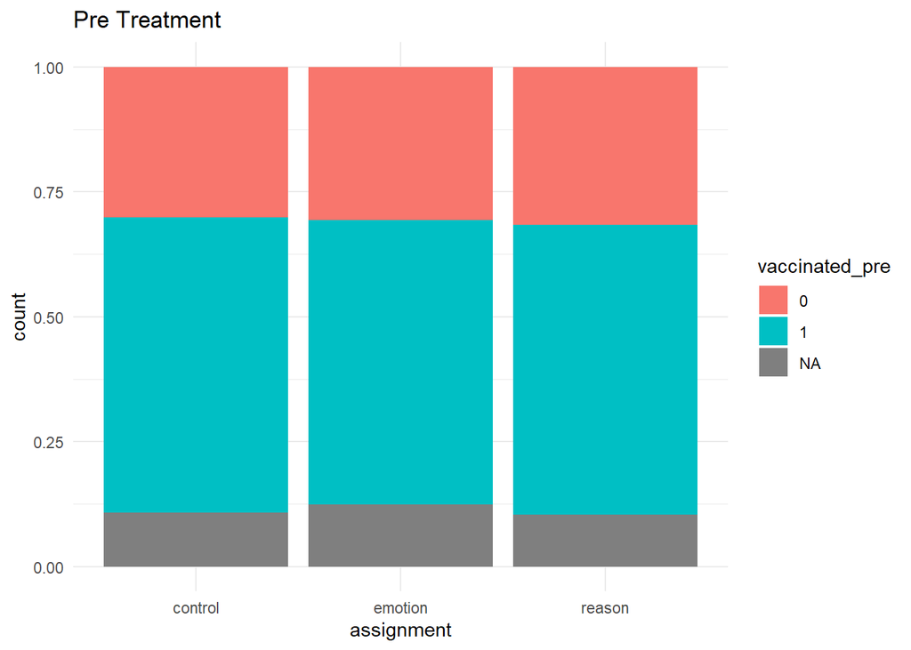

```r
#Bar plot of outcomes for each treatment group
ggplot(baseline_survey, aes(x = assignment, fill = vaccinated_pre)) +
  geom_bar(position = "fill", stat = "count") +
  theme_minimal() + ggtitle("Pre Treatment")
```

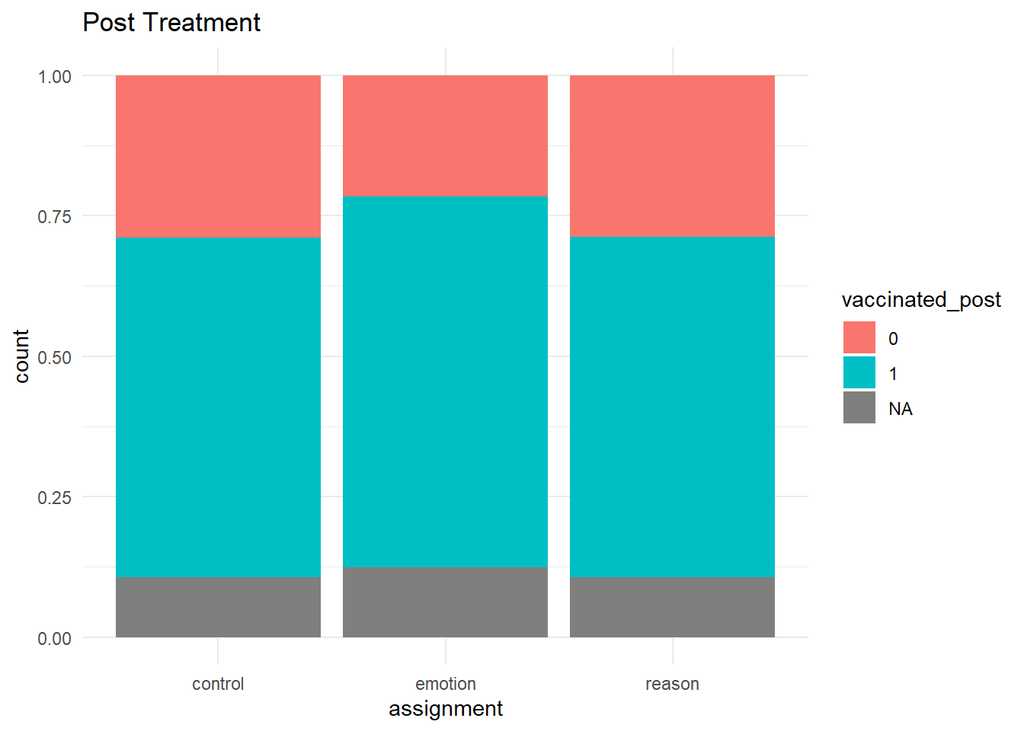

```r
#Bar plot of outcomes for each treatment group
ggplot(endline_survey,aes(x = assignment, fill = vaccinated_post)) + geom_bar(position ="fill", stat = "count") + theme_minimal() + ggtitle("Post Treatment")
```

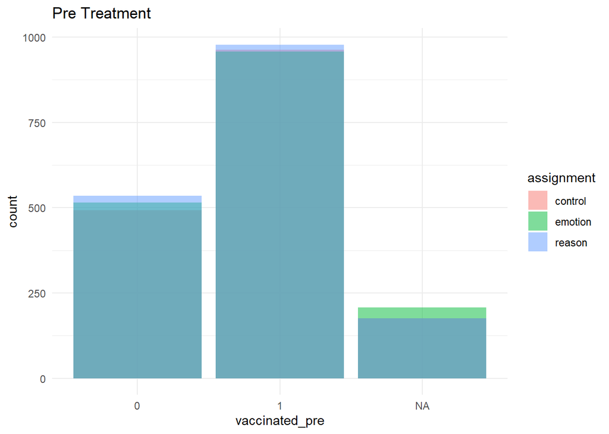

```r
#Histogram of outcomes by group in baseline
ggplot(baseline_survey, aes(x = vaccinated_pre, fill = assignment)) + geom_histogram(binwidth = 1, position = "identity", alpha = 0.5, stat="count") + theme_minimal() + ggtitle("Pre Treatment")
```

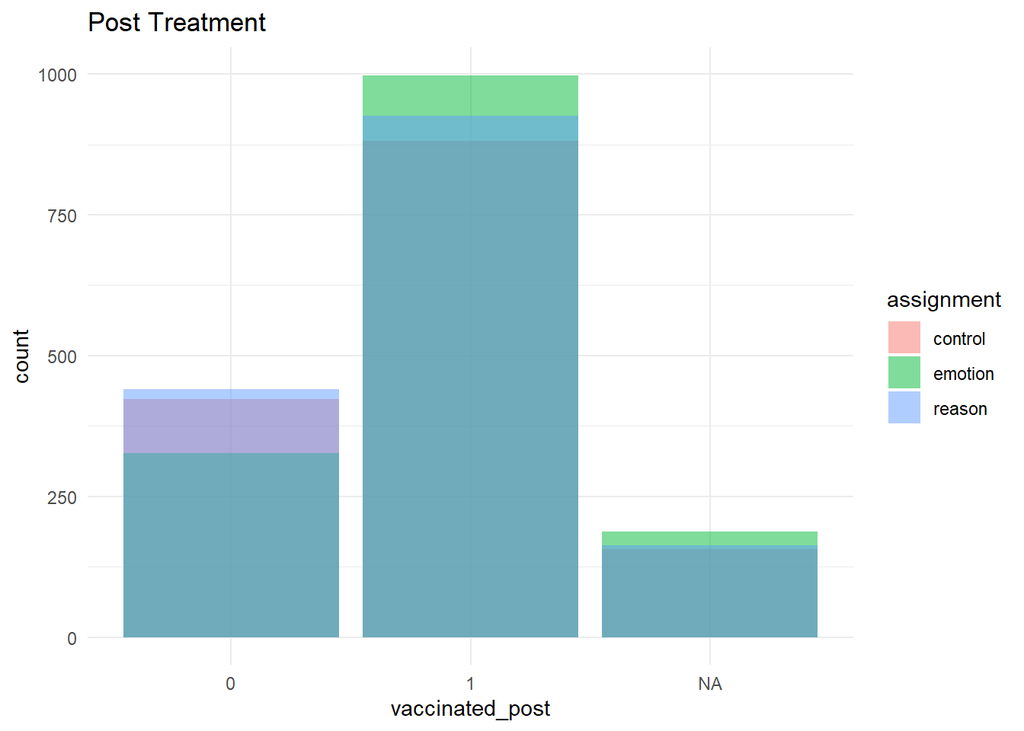

```r
#Histogram of outcomes by group in endline
ggplot(endline_survey, aes(x= vaccinated_post, fill = assignment)) + geom_histogram(binwidth = 1, position = "identity", alpha = 0.5, stat="count") + theme_minimal() + ggtitle("Post Treatment")
```

## Regressions

### Univariate Analysis

The following section are the univariate regressions of the treatments of the vaccine intake outcomes, both for first time vaccinations and on those who have vaccines already getting a booster shot.

Because this is an RCT, if we’re assuming the randomization is successful, comparing the average treatment outcomes of each group should yield us a causal estimate:

$ATE = E[Y|T = 1] - E[Y|T=0]$

Where Y is a vaccination outcome, and T is some treatment, either reason or emotional. These regressions are of the following specification:

$Y_{post} = \alpha + \beta T + \epsilon$

```r
## Univariate regressions

reg_adverts <- lm(vaccinated_post ~ assignment.1, data = combined_data)
stargazer(reg_adverts, title = "Emotional vs reason Adverts on Vaccine Uptake", type = "text")
```

```
##
## Emotional vs reason Adverts on Vaccine Uptake
## ===============================================
##                         Dependent variable:
##                     ---------------------------
##                           vaccinated_post
## -----------------------------------------------
## assignment.1emotion          0.078***
##                               (0.018)
##
## assignment.1reason             0.002
##                               (0.018)
##
## Constant                     0.676***
##                               (0.013)
##
## -----------------------------------------------
## Observations                   3,994
## R2                             0.006
## Adjusted R2                    0.006
## Residual Std. Error      0.456 (df = 3991)
## F Statistic          12.627*** (df = 2; 3991)
## ===============================================
## Note:               *p<0.1; **p<0.05; ***p<0.01
```

```r
#Data set of those who were already vaccinated
already_vaccinated <- combined_data %>%
  filter(vaccinated_pre.1 == 1)

reg_adverts_on_vaccinated <- lm(booster_post ~ assignment.1, data = already_vaccinated)
stargazer(reg_adverts_on_vaccinated, title = "Adverts on Vaccine Uptake (boosters) Among Already Vaccinated", type = "text")
```

```
##
## Adverts on Vaccine Uptake (boosters) Among Already Vaccinated
## ===============================================
##                         Dependent variable:
##                     ---------------------------
##                            booster_post
## -----------------------------------------------
## assignment.1emotion           -0.012
##                               (0.021)
##
## assignment.1reason           0.124***
##                               (0.021)
##
## Constant                     0.696***
##                               (0.015)
##
## -----------------------------------------------
## Observations                   2,603
## R2                             0.019
## Adjusted R2                    0.019
## Residual Std. Error      0.438 (df = 2600)
## F Statistic          25.736*** (df = 2; 2600)
## ===============================================
## Note:               *p<0.1; **p<0.05; ***p<0.01
```

```r
#Data set of those who were not vaccinated before
not_vaccinated <- combined_data %>%
  filter(vaccinated_pre.1 == 0)

reg_adverts_on_unvaccinated <- lm(vaccinated_post ~ assignment.1, data = not_vaccinated)
stargazer(reg_adverts_on_unvaccinated, title = "Adverts on Vaccine Uptake Among Unvaccinated in Pre-period", type = "text")
```

```
##
## Adverts on Vaccine Uptake Among Unvaccinated in Pre-period
## ===============================================
##                         Dependent variable:
##                     ---------------------------
##                           vaccinated_post
## -----------------------------------------------
## assignment.1emotion          0.271***
##                               (0.022)
##
## assignment.1reason           0.063***
##                               (0.022)
##
## Constant                      0.032**
##                               (0.016)
##
## -----------------------------------------------
## Observations                   1,391
## R2                             0.107
## Adjusted R2                    0.106
## Residual Std. Error      0.333 (df = 1388)
## F Statistic          83.551*** (df = 2; 1388)
## ===============================================
## Note:               *p<0.1; **p<0.05; ***p<0.01
```

These results seem to suggest that overall, emotion is more effective than reason. There is a 7.8% point increase on average when exposed to the advertisement that utilizes emotion; this is statistically significant with a p-value of less than 0.01.

However, we can break this down further by looking at specific populations, those who were already vaccinated seem to resonate with the adverts for reason more than emotion. This led to booster shot uptake increasing by 12.4% points on average. With a p-value of less than 0.01.

For those who weren’t vaccinated specifically, it seems to be the case that emotion and reason had a statistically significant impact with low p-values, but emotion was much more effective with a 27.1% point increase while reason was on average assocaited with a 6.3% point increase.

### Multivariate Analysis

Although this is an RCT, and comparing mean outcomes of treat and control should yield us a causal estimate, it’s valuable to regress while controlling for key demographic indicators. Below is the specification for the following regressions

$Y_{post} = \alpha + \beta T + \delta Indicator +\epsilon$

```r
## Regressions controlling for demographics

reg_adverts_controls <- lm(vaccinated_post ~ assignment.1 + state.1 + age.1 + race.1 + Hispanic.1 + affiliation.1 + education.1, data = combined_data)
stargazer(reg_adverts_controls, title = "Emotional vs reason Adverts on Vaccine Uptake", type = "text")
```

```
##
## Emotional vs reason Adverts on Vaccine Uptake
## =======================================================
##                                 Dependent variable:
##                             ---------------------------
##                                   vaccinated_post
## -------------------------------------------------------
## assignment.1emotion                  0.080***
##                                       (0.020)
##
## assignment.1reason                     0.004
##                                       (0.020)
##
## state.1Alaska                          0.192
##                                       (0.186)
##
## state.1Arizona                         0.005
##                                       (0.085)
##
## state.1Arkansas                        0.044
##                                       (0.099)
##
## state.1California                      0.027
##                                       (0.068)
##
## state.1Colorado                       -0.081
##                                       (0.096)
##
## state.1Connecticut                     0.036
##                                       (0.098)
##
## state.1Delaware                       -0.045
##                                       (0.151)
##
## state.1District of Columbia           -0.077
##                                       (0.172)
##
## state.1Florida                        -0.013
##                                       (0.070)
##
```

[output cut: 155 more lines]

```
##
## education.1No high school             -0.002
##                                       (0.031)
##
## Constant                             0.754***
##                                       (0.076)
##
## -------------------------------------------------------
## Observations                           3,114
## R2                                     0.045
## Adjusted R2                            0.025
## Residual Std. Error              0.451 (df = 3049)
## F Statistic                  2.249*** (df = 64; 3049)
## =======================================================
## Note:                       *p<0.1; **p<0.05; ***p<0.01
```

```r
reg_adverts_on_vaccinated_controls <- lm(booster_post ~ assignment.1 + state.1 + age.1 + race.1 + Hispanic.1 + affiliation.1 + education.1, data = already_vaccinated)
stargazer(reg_adverts_on_vaccinated_controls, title = "Adverts on Vaccine Uptake (boosters) Among Already Vaccinated", type = "text")
```

```
##
## Adverts on Vaccine Uptake (boosters) Among Already Vaccinated
## =======================================================
##                                 Dependent variable:
##                             ---------------------------
##                                    booster_post
## -------------------------------------------------------
## assignment.1emotion                   -0.016
##                                       (0.024)
##
## assignment.1reason                   0.136***
##                                       (0.024)
##
## state.1Alaska                          0.167
##                                       (0.200)
##
## state.1Arizona                         0.053
##                                       (0.105)
##
## state.1Arkansas                       0.222*
##                                       (0.123)
##
## state.1California                      0.074
##                                       (0.086)
##
## state.1Colorado                        0.128
##                                       (0.124)
##
## state.1Connecticut                    0.199*
##                                       (0.117)
##
## state.1Delaware                        0.023
##                                       (0.185)
##
## state.1District of Columbia            0.295
##                                       (0.235)
##
## state.1Florida                         0.044
##                                       (0.089)
##
```

[output cut: 152 more lines]

```
##
## education.1No high school              0.018
##                                       (0.037)
##
## Constant                             0.620***
##                                       (0.093)
##
## -------------------------------------------------------
## Observations                           2,025
## R2                                     0.050
## Adjusted R2                            0.019
## Residual Std. Error              0.439 (df = 1961)
## F Statistic                  1.635*** (df = 63; 1961)
## =======================================================
## Note:                       *p<0.1; **p<0.05; ***p<0.01
```

```r
reg_adverts_on_unvaccinated_controls <- lm(vaccinated_post ~ assignment.1 + state.1 + age.1 + race.1 + Hispanic.1 + affiliation.1 + education.1, data = not_vaccinated)
stargazer(reg_adverts_on_unvaccinated_controls, title = "Adverts on
Vaccine Uptake Among Unvaccinated in Pre-period", type = "text")
```

[output not shown]

[output cut: 155 more lines]

```
##
## education.1No high school             -0.007
##                                       (0.039)
##
## Constant                               0.034
##                                       (0.094)
##
## -------------------------------------------------------
## Observations                           1,089
## R2                                     0.160
## Adjusted R2                            0.108
## Residual Std. Error              0.338 (df = 1024)
## F Statistic                  3.048*** (df = 64; 1024)
## =======================================================
## Note:                       *p<0.1; **p<0.05; ***p<0.01
```

It seems that even after controlling for demographic information, we maintain the same results of the emotion advert being more effective overall at the same level of significance. For those who received a shot already, it seems again that reason was more effective; the opposite was true again for those who hadn’t gotten vaccinated.

# Conclusion

Taking the results into consideration, I did not find evidence that the assignment of treatments failed to be random, this seems to be a valid RCT. From the data visualization and regression analysis that followed, we found stark increases on vaccine uptake of both types of treatments on different populations. This heterogeneity is clouded when regressing the treatments on the entire population, and it was revealed that ads that employed reason were more likely to convince those who were vaccinated already to get a booster shot, while those who weren’t already vaccinated resonated more with the emotional adverts, but still were impacted by the advertisements that employed reason, if to a lesser extent.